# Лабораторная работа №3

[figure not shown]

Код из jupyter notebook

Создаем, заполняем и запускаем файл, который ищет оптимальные комбинации параметров, минимизирующие одновременно два критерия: пиковую заболеваемость и долю умерших.

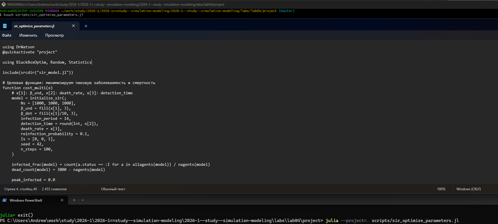

Создание файла оптимизации параметров

Результаты выведет в консоль. Там буду оптимизированые мараметры для минимизации.

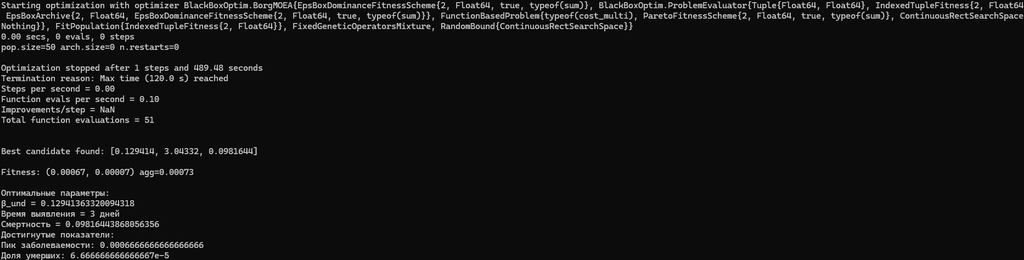

Результат оптимизации

Преобразовываем код в произвольные стили, открываем jupyter файл и убеждаемся в правильной компиляции.

[figure not shown]

Код из jupyter notebook

Создаем файл, который на основе предыдущих результатов будет создавать сводную визуализацию

[figure not shown]

Сводная визуализация результатов

Получаем общий график, созданный на основе посчитанных ранее данных

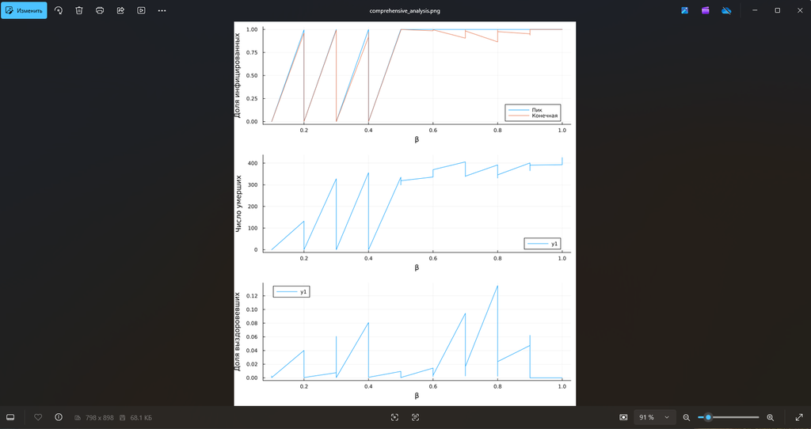

График

Преобразовываем код в произвольные стили, открываем jupyter файл и убеждаемся в правильной компиляции.

[figure not shown]

Код из jupyter notebook

## Выводы

В данной работе мы разобрались с агентным моделированием и реализовали его на практике.